# Ngôn ngữ Python

# Thư viện Panda

## Bài 1: Giới thiệu và cài đặt pandas

### Cài đặt: “pip install pandas”

- “pandas” là thư viện mở rộng từ numpy, chuyên để xử lý dữ liệu cấu trúc dạng bảng
- Tên “pandas” là dạng số nhiều của “panel data”

### Đặc điểm nổi bật của pandas

- Đọc dữ liệu từ nhiều định dạng
- Liên kết dữ liệu và tích hợp xử lý dữ liệu bị thiếu
- Xoay và chuyển đổi chiều của dữ liệu dễ dàng
- Tách, đánh chỉ mục và chia nhỏ các tập dữ liệu lớn dựa trên nhãn
- Có thể nhóm dữ liệu cho các mục đích hợp nhất và chuyển đổi
- Lọc dữ liệu và thực hiện query trên dữ liệu
- Xử lý dữ liệu chuỗi thời gian và lấy mẫu

## Bài 2: Cấu trúc dữ liệu trong pandas

### Cấu trúc dữ liệu trong pandas

📌 Cấu trúc dữ liệu chính trong Pandas

- **Series (loạt):** cấu trúc 1 chiều, mảng dữ liệu đồng nhất.
- **DataFrame (khung):** cấu trúc 2 chiều, dữ liệu trên các cột là đồng nhất (giống như bảng trong SQL, nhưng có thêm tên cho các dòng).
- **Panel (bảng):** cấu trúc 3 chiều, có thể xem như một tập các DataFrame với thông tin bổ sung

🔹 Điểm khác biệt của Series so với NumPy array

- Chấp nhận dữ liệu thiếu (**NaN – Not a Number / giá trị không xác định**).
- Có hệ thống chỉ mục (**Index**) linh hoạt, giống như dictionary trong Python.

### Cấu trúc dataframe

- Dữ liệu 2 chiều
- Các cột có tên
- Dữ liệu trên cột là đồng nhất (series?)
- Các dòng có thể có tên
- Có thể có ô thiếu dữ liệu

### Cấu trúc panel

- Dữ liệu 3 chiều
- Một tập các dataframe
- Các dataframe có cấu trúc tương đồng
- Có thể có các thông tin bổ sung cho từng dataframe

## Bài 3: Làm việc với series

### Tạo dữ liệu series (1)

```python
import pandas as pd
import numpy as np

# Tạo Series gồm 4 phần tử ngẫu nhiên từ 0 đến 99
S = pd.Series(np.random.randint(100, size=4))

# In toàn bộ Series
print("Series:")
print(S)

# In chỉ mục (index)
print("\nIndex của Series:")
print(S.index)

# In giá trị (values)
print("\nGiá trị của Series:")
print(S.values)
```

```
Series:
0    29
1    43
2     8
3    16
dtype: int64

Index của Series:
RangeIndex(start=0, stop=4, step=1)

Giá trị của Series:
[29 43  8 16]
```

### Tạo dữ liệu series (2)

```python
import pandas as pd
import numpy as np

# Danh sách chỉ số (index)
chi_so = ["Ke toan", "KT", "CNTT", "Co khi"]

# Danh sách giá trị
gia_tri = [310, 360, 580, 340]

# Tạo Series với index tự đặt
S = pd.Series(gia_tri, index=chi_so)

# In Series
print("Series với index tùy chỉnh:")
print(S)

# In index
print("\nIndex của Series:")
print(S.index)

# In giá trị
print("\nGiá trị của Series:")
print(S.values)
```

```
Series với index tùy chỉnh:
Ke toan    310
KT         360
CNTT       580
Co khi     340
dtype: int64

Index của Series:
Index(['Ke toan', 'KT', 'CNTT', 'Co khi'], dtype='object')

Giá trị của Series:
[310 360 580 340]
```

### Tạo dữ liệu series (3)

```python
import pandas as pd
import numpy as np

chi_so = ["KT", "KT", "CNTT", "Co khi"]  # có index trùng nhau
gia_tri = [310, 360, 580, 340]

S = pd.Series(gia_tri, index=chi_so)

print("Series với index trùng nhau:")
print(S)

print("\nIndex của Series:")
print(S.index)

print("\nGiá trị của Series:")
print(S.values)
```

```
Series với index trùng nhau:
KT        310
KT        360
CNTT      580
Co khi    340
dtype: int64

Index của Series:
Index(['KT', 'KT', 'CNTT', 'Co khi'], dtype='object')

Giá trị của Series:
[310 360 580 340]
```

### Truy vấn dữ liệu thông qua chỉ số

```python
import pandas as pd
import numpy as np

chi_so = ["KT", "KT", "CNTT", "Co khi"]  # trùng nhau
gia_tri = [310, 360, 580, 340]
S = pd.Series(gia_tri, index=chi_so)

print(S['Co khi'])  # truy cập theo index "Co khi"
print(S['KT'])      # truy cập theo index "KT" (trùng, sẽ trả về nhiều giá trị)
print(S.CNTT)       # truy cập kiểu attribute (chỉ dùng được khi tên index hợp lệ)
```

```
340
KT    310
KT    360
dtype: int64
580
```

### Phép toán trên series

```python
import pandas as pd
import numpy as np

# Series S với index tùy chỉnh
chi_so = ["Ke toan", "KT", "CNTT", "Co khi"]
gia_tri = [310, 360, 580, 340]
S = pd.Series(gia_tri, index=chi_so)

# Series P
P = pd.Series([100, 100], index=["CNTT", "PM"])

# Cộng 2 Series
Y = S + P
print("Kết quả cộng 2 Series:")
print(Y)
```

```
Kết quả cộng 2 Series:
CNTT       680.0
Co khi       NaN
KT           NaN
Ke toan      NaN
PM           NaN
dtype: float64
```

Nguyên tắc chung của việc thực hiện phép toán trên series như sau:

- Nếu là phép toán giữa 2 series, thì các giá trị cùng chỉ số sẽ thực hiện phép toán với nhau, trường hợp không có giá trị ở cả 2 series thì trả về NaN
- Nếu là phép toán giữa series và 1 số, thì thực hiện phép toán trên số đó với tất cả các giá trị trong series

### Một số phương thức hữu ích

- S.axes: trả về danh sách các chỉ mục của S
- S.dtype: trả về kiểu dữ liệu các phần tử của S
- S.empty: trả về True nếu S rỗng
- S.ndim: trả về số chiều của S (1)
- S.size: trả về số phần tử của S
- S.values: trả về list các phần tử của S
- S.head(n): trả về n phần tử đầu tiên của S
- S.tail(n): trả về n phần tử cuối cùng của S

#### apply() một hàm khác trên series

```python
import pandas as pd
import numpy as np

# Hàm xử lý giá trị
def Tang(x):
    return x if x > 500 else x + 1000

# Dữ liệu
chi_so = ["Ke toan", "KT", "CNTT", "Co khi"]
gia_tri = [310, 360, 580, 340]

# Tạo Series
S = pd.Series(gia_tri, index=chi_so)

# Áp dụng hàm Tang (không thay đổi S gốc)
print("Series ban đầu:")
print(S)

print("\nSeries sau khi áp dụng Tang:")
print(S.apply(Tang))
```

```
Series ban đầu:
Ke toan    310
KT         360
CNTT       580
Co khi     340
dtype: int64

Series sau khi áp dụng Tang:
Ke toan    1310
KT         1360
CNTT        580
Co khi     1340
dtype: int64
```

## Bài 4: Làm việc với dataframe

### Khởi tạo dataframe

- Cú pháp chung: pandas.DataFrame(data, index, columns, dtype, copy)
- Trong đó:
  - ‘data’ sẽ nhận giá trị từ nhiều kiểu khác nhau như list, dictionary, ndarray, series,... và cả các DataFrame khác
  - ‘index’ là nhãn chỉ mục hàng của dataframe
  - ‘columns’ là nhãn chỉ mục cột của dataframe
  - ‘dtype’ là kiểu dữ liệu cho mỗi cột
  - ‘copy’ nhận giá trị True/False để chỉ rõ dữ liệu có được copy sang vùng nhớ mới không, mặc định là False

### Tạo dataframe từ list

```python
import pandas as pd

# Dữ liệu dạng dictionary
crimes_rates = {
    "Year": [1960, 1961, 1962, 1963, 1964],
    "Population": [179323175, 182992000, 185771000, 188483000, 191141000],
    "Total": [3384200, 3488000, 3752200, 4109500, 4564600],
    "Violent": [288460, 289390, 301510, 316970, 364220]
}

# Tạo DataFrame từ dict
crimes_dataframe = pd.DataFrame(crimes_rates)

# In ra DataFrame
print(crimes_dataframe)
```

```
   Year  Population    Total  Violent
0  1960   179323175  3384200   288460
1  1961   182992000  3488000   289390
2  1962   185771000  3752200   301510
3  1963   188483000  4109500   316970
4  1964   191141000  4564600   364220
```

### Tạo dataframe từ list các dictionary

```python
import pandas as pd

# Tạo dữ liệu dạng list of dicts
data = [
    {'MIT': 5000, 'Stanford': 4500, "DHTL": 15000},
    {'MIT': 1, 'Stanford': 2, "DHTL": 200}
]

# Tạo DataFrame và đặt index
df = pd.DataFrame(data, index=['NumOfStudents', "ranking"])

print(df)              # In DataFrame
print(df.DHTL.dtype)   # Kiểu dữ liệu của cột "DHTL"
```

```
                MIT  Stanford   DHTL
NumOfStudents  5000      4500  15000
ranking           1         2    200
int64
```

### Tạo dataframe từ dictionary serias

```python
import pandas as pd

data = {
    "one": pd.Series([1, 23, 45], index=[1, 2, 3]),
    "two": pd.Series([1000, 2400, 1132, 3434], index=[1, 2, 3, 4])
}

df = pd.DataFrame(data)
print(df)
```

```
    one   two
1   1.0  1000
2  23.0  2400
3  45.0  1132
4   NaN  3434
```

### Đọc dữ liệu từ file .csv

- Nội dung của file brics.csv:
  - Số liệu về các quốc gia thuộc khối BRICS
  - Sử dụng dấu phẩy để ngăn giữa các dữ liệu
  - Mỗi dữ liệu trên 1 dòng
  - Dòng đầu tiên là tên các cột

```python
import pandas as pd

# Tạo file brics.csv từ dữ liệu bạn đưa
data = """,country,population,area,capital
BR,Brazil,200,8515767,Brasilia
RU,Russia,144,17098242,Moscow
IN,India,1252,3287590,New Delhi
CH,China,1357,9596961,Beijing
SA,South Africa,55,1221037,Pretoria
"""

with open("brics.csv", "w") as f:
    f.write(data)

# Đọc file bằng pandas
df = pd.read_csv("brics.csv")
print(df)
```

```
  Unnamed: 0       country  population      area    capital
0         BR        Brazil         200   8515767   Brasilia
1         RU        Russia         144  17098242     Moscow
2         IN         India        1252   3287590  New Delhi
3         CH         China        1357   9596961    Beijing
4         SA  South Africa          55   1221037   Pretoria
```

```python
import pandas as pd

# đọc dữ liệu và quy định cột 0 dùng làm chỉ số dòng
d = pd.read_csv("brics.csv", index_col = 0)
print(d)
```

```
         country  population      area    capital
BR        Brazil         200   8515767   Brasilia
RU        Russia         144  17098242     Moscow
IN         India        1252   3287590  New Delhi
CH         China        1357   9596961    Beijing
SA  South Africa          55   1221037   Pretoria
```

### Truy cập theo từng cột

- Sử dụng tên cột làm chỉ số hoặc dùng luôn tên cột
- Việc truy cập này trả về tham chiếu đến dữ liệu, vì vậy có thể sử dụng phép gán để cập nhật dữ liệu theo cột

### Thêm một cột (1)

- Bằng cách sử dụng một cột mới chưa có

```python
import pandas as pd

# Đọc dữ liệu từ file CSV
brics = pd.read_csv("brics.csv")

# Thêm cột mới on_earth với giá trị True cho tất cả các dòng
brics["on_earth"] = [True, True, True, True, True]

# In ra bảng
print(brics)
```

```
  Unnamed: 0       country  population      area    capital  on_earth
0         BR        Brazil         200   8515767   Brasilia      True
1         RU        Russia         144  17098242     Moscow      True
2         IN         India        1252   3287590  New Delhi      True
3         CH         China        1357   9596961    Beijing      True
4         SA  South Africa          55   1221037   Pretoria      True
```

### Thêm một cột (2)

- Bằng cách sử dụng một cột mới chưa có và thiết lập công thức phù hợp

```python
import pandas as pd

# Đọc dữ liệu
brics = pd.read_csv("brics.csv")

# Thêm cột mật độ dân số
brics["density"] = brics["population"] / brics["area"] * 1000000

# In ra kết quả
print(brics)
```

```
  Unnamed: 0       country  population      area    capital     density
0         BR        Brazil         200   8515767   Brasilia   23.485847
1         RU        Russia         144  17098242     Moscow    8.421918
2         IN         India        1252   3287590  New Delhi  380.826076
3         CH         China        1357   9596961    Beijing  141.398928
4         SA  South Africa          55   1221037   Pretoria   45.043680
```

### Truy cập vào từng ô trên dataframe

- Bằng cách kết hợp chỉ mục dòng và cột

```python
import pandas as pd

brics = pd.read_csv("brics.csv", index_col=0)

print(brics.loc["CH", "capital"])  # Kết quả: Beijing

print(brics["capital"].loc["CH"])

print(brics.loc["CH", "capital"])
```

```
Beijing
Beijing
Beijing
```

### Xóa dòng hoặc cột bằng drop

```python
import pandas as pd

# Ví dụ: đọc file CSV
d = pd.read_csv("brics.csv", index_col=0)

# Tạo DataFrame mới bằng cách xóa 2 cột (không ảnh hưởng đến d gốc)
print(d.drop(["area", "population"], axis=1))

# Xóa trực tiếp trên d bằng inplace=True
d.drop(["area", "population"], axis=1, inplace=True)
print(d)
```

```
         country    capital
BR        Brazil   Brasilia
RU        Russia     Moscow
IN         India  New Delhi
CH         China    Beijing
SA  South Africa   Pretoria
         country    capital
BR        Brazil   Brasilia
RU        Russia     Moscow
IN         India  New Delhi
CH         China    Beijing
SA  South Africa   Pretoria
```

### Tính tổng và tổng tích lũy

```python
import pandas as pd

# Ví dụ DataFrame
d = pd.read_csv("brics.csv", index_col=0)

# Tổng toàn bộ cột population
print(d.population.sum())

# Tính tổng tích lũy (cumulative sum) theo từng dòng
print(d.population.cumsum())
```

```
3008
BR     200
RU     344
IN    1596
CH    2953
SA    3008
Name: population, dtype: int64
```

### Kết hợp giữa pandas và matplotlib

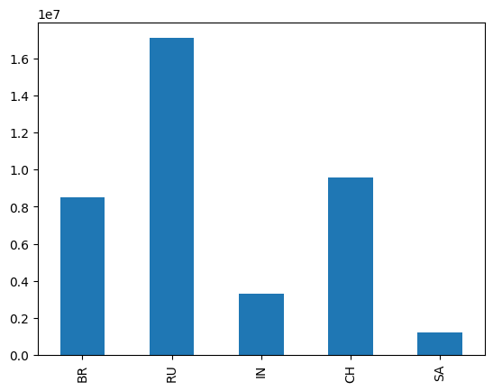

```python
import pandas as pd
import matplotlib.pyplot as plt

# Đọc dữ liệu từ file CSV, lấy cột "country" làm index
d = pd.read_csv("brics.csv", index_col=0)

# Vẽ biểu đồ cột cho cột "area"
d.area.plot(kind='bar')

# Hiển thị biểu đồ
plt.show()
```